# Using a Custom Theme in Quarto Documents

quarto

styling

customization

Author

Data Explorer

Published

December 19, 2023

# Custom Theme Integration

This document demonstrates how Quarto documents can have their own independent theme. Each document can specify its own typography, colors, spacing, and other design elements.

## How It Works

Using Quarto’s theming system:

1. Specify a theme in the YAML frontmatter (`theme: cosmo` in this case)
2. Add custom CSS for additional styling if needed
3. Each document can have a completely different look and feel

Here are examples of elements using the custom theme:

## Typography Demo

Text in this document uses the Cosmo theme’s default font family and sizes.

### Headings Use the Theme Style

Headings use the theme’s heading font, sizes, and colors.

> Blockquotes adopt the theme’s accent color and styling.

## Code Examples

Code blocks use your website’s code styling:

```python
# Python example
def greet(name):
    """Say hello to someone"""
    return f"Hello, {name}!"

# Let's try it
message = greet("World")
print(message)  # Outputs: Hello, World!
```

And here’s some R code:

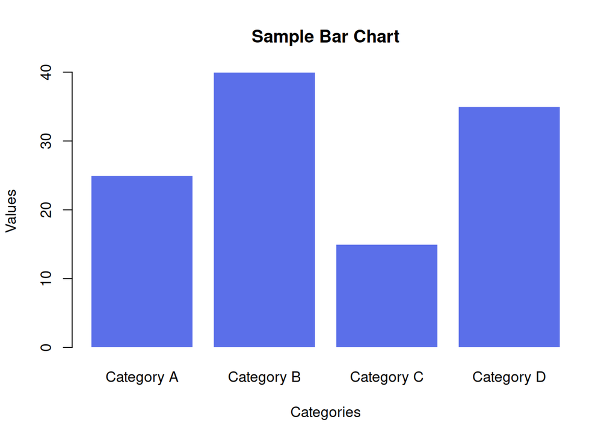

A simple bar plot styled with the website’s theme

```r
# Create a simple dataset
categories <- c("Category A", "Category B", "Category C", "Category D")
values <- c(25, 40, 15, 35)
data <- data.frame(Category = categories, Value = values)

# Create a bar plot
barplot(data$Value,
        names.arg = data$Category,
        col = "#5b6fe9",
        main = "Sample Bar Chart",
        xlab = "Categories",
        ylab = "Values",
        border = "white")
```

## Tables

Tables also inherit your website’s styling:

| Feature | Description | Status |
| --- | --- | --- |
| Typography | Fonts, sizes, and colors | ✓ |
| Code blocks | Syntax highlighting and background | ✓ |
| Tables | Border styles and backgrounds | ✓ |
| Interactive elements | Buttons, inputs, and controls | ✓ |
| Responsive design | Adapts to different screen sizes | ✓ |

## Theme Benefits

This document showcases independent theme styling with benefits like:

- Custom background and text colors
- Typography and font styling specific to this document
- Document-specific spacing and layout conventions
- Unique link and accent colors
- Component styling tailored to content
- Visual hierarchy optimized for the document

## Benefits of Independent Theming

With independent themes for each Quarto document:

1. **Content-appropriate styling** for different types of documents
2. **Freedom to experiment** with different visual styles
3. **Specialized styling** for technical vs non-technical content
4. **Easier migration** as documents can be moved to other sites

## Implementation

To use a custom theme in your own Quarto documents, add these lines to your document’s YAML header:

```yaml
format:
  html:
    theme: cosmo  # or any other Quarto theme
    css: custom.css  # optional custom CSS
    minimal: true
    page-layout: article
    toc: true
    code-fold: false
    code-tools: true
    self-contained: true
    embed-resources: true
```

## Conclusion

With this approach, each Quarto document can have its own styling optimized for its specific content while leveraging Quarto’s powerful computational features.